# Nuisance Correction

## White Matter & Stimulus Correlation Investigation

### 3/13/17 Deliverable

Goal: For task-based fMRI datasets, verify that the 5 components from white matter obtained from our current compcor method for nuisance correction do not correlate with the task-based stimulus.

Emotion task: "Participants are presented with blocks of trials that either ask them to decide which of two faces presented on the bottom of the screen match the face at the top of the screen, or which of two shapes presented at the bottom of the screen match the shape at the top of the screen. The faces have either an angry or fearful expression. Trials are presented in blocks of 6 trials of the same task (face or shape), with the stimulus presented for 2000 ms and a 1000 ms ITI. Each block is preceded by a 3000 ms task cue (“shape” or “face”), so that each block is 21 seconds including the cue. Each of the two runs includes 3 face blocks and 3 shape blocks, with 8 seconds of fixation at the end of each run."

Motor task: " Participants are presented with visual cues that ask them to either tap their left or right fingers, or squeeze their left or right toes, or move their tongue to map motor areas. Each block of a movement type lasted 12 seconds (10 movements), and is preceded by a 3 second cue. In each of the two runs, there are 13 blocks, with 2 of tongue movements, 4 of hand movements (2 right and 2 left), and 4 of foot movements (2 right and 2 left)."

The five components of the white matter obtained from the nuisance correction were correlated with a hemodynamic response that had been convolved with the stimulus onset timeseries. The components of the white matter were determined from the following code:

```python
from ndmg.utils import utils as mgu
import nibabel as nb
import numpy as np
import scipy.signal as signal
fmri = './data/motor_output/reg_fmri/101107_3T_tfMRI_MOTOR_LR_aligned.nii.gz'
amri = './data/motor_output/reg_struct/101107_3T_tfMRI_MOTOR_LR_anat_aligned.nii.gz'
amask = './FNGS_server/atlases/mask/MNI152_T1-2mm_brain_mask.nii.gz'
an = 1
outdir = './'
lvmask = './FNGS_server/atlases/mask/HarvOx_lv_thr25-2mm.nii.gz'
amask_im = nb.load(amask)
amm = amask_im.get_data()
lv_im = nb.load(lvmask)
lvm = lv_im.get_data()
fmri_name = mgu().get_filename(fmri)
anat_name = mgu().get_filename(amri)
nuisname = "".join([anat_name, "_nuis"])
map_path = mgu().name_tmps(outdir, nuisname, "_map")
wmm_path = mgu().name_tmps(outdir, nuisname, "_wm_mask.nii.gz")
er_wmm_path = mgu().name_tmps(outdir, nuisname, "_eroded_wm_mask.nii.gz")
cmd1 = " ".join(["fast -t", str(int(an)), "-n 3 -o", map_path, amri])
mgu().execute_cmd(cmd1)
wm_prob = map_path + "_pve_2.nii.gz"
prob = nb.load(wm_prob)
prob_dat = prob.get_data()
mask = (prob_dat > .99).astype(int)
img = nb.Nifti1Image(mask,header = prob.header,affine = prob.get_affine())
nb.save(img, wmm_path)
mask_img = nb.load(wmm_path)
mask = mask_img.get_data()
for i in range(0, 2):
    erode_mask = np.zeros(mask.shape)
    x, y, z = np.where(mask != 0)
    if (x.shape == y.shape and y.shape == z.shape):
        for j in range(0, x.shape[0]):
            md = mask.shape
            if (mask[x[j],y[j],z[j]] and
                mask[np.min((x[j]+1, md[0]-1)),y[j],z[j]] and
                mask[x[j],np.min((y[j]+1, md[1]-1)),z[j]] and
                mask[x[j],y[j],np.min((z[j]+1, md[2]-1))] and
                mask[np.max((x[j]-1, 0)),y[j],z[j]] and
                mask[x[j],np.max((y[j]-1, 0)),z[j]] and
                mask[x[j],y[j],np.max((z[j]-1, 0))]):
                erode_mask[x[j],y[j],z[j]] = 1
    else:
        raise ValueError('Your mask erosion has an invalid shape.')
    mask = erode_mask

eroded_mask_img = nb.Nifti1Image(mask,header = mask_img.header,affine = mask_img.get_affine())
nb.save(eroded_mask_img, er_wmm_path)
wmm = mask
fmri_im = nb.load(fmri)
amri_im = nb.load(amri)
fmri_dat = fmri_im.get_data()
voxel = fmri_dat[fmri_dat.sum(axis=3) > 0, :].T
wm_ts = fmri_dat[wmm != 0, :].T
lv_ts = fmri_dat[lvm != 0, :].T
t = voxel.shape[0]
lin_reg = np.array(range(0, t))
quad_reg = np.array(range(0, t))**2
csf_reg = lv_ts.mean(axis=1)
wm_ts = wm_ts[:, wm_ts.std(axis=0) != 0]
wm_ts = signal.detrend(wm_ts, axis=0, type='linear')
wm_ts = wm_ts - wm_ts.mean(axis=0)
wm_ts = np.divide(wm_ts, wm_ts.std(axis=0))
U, s, V = np.linalg.svd(wm_ts)
wm_reg = U[:, 0:5]
np.savetxt('./data/motor_output/wmreg_101107_motor.txt', wm_reg)
```

The hemodynamic response timeseries for the emotion task was generated by the following code:

```python
import numpy as np
from nipy.modalities.fmri import hrf, utils
hrf_func = utils.lambdify_t(hrf.glover(utils.T))
tsteps = 136
frames = 176
e = np.true_divide(tsteps,frames)
e = np.multiply(e, frames-1)
t = np.linspace(0,e,frames)
h = hrf_func(t)
s = np.zeros(frames)
s[4]=1    # 3 sec
s[31]=1   # 24 sec
s[58]=1   # 45 sec
s[85]=1   # 66 sec
s[113]=1  # 87 sec
s[140]=1  # 108 sec
x = np.convolve(h,s)
x = x[:frames]
np.savetxt('./data/emotion_output/hs_emotion.txt', x)
```

This was then evaluated as follows:

```python
%matplotlib inline
import numpy as np
import matplotlib.pyplot as plt
tsteps = 176
wmc = 5
fnames = ['./wmreg_101107_emotion.txt', './wmreg_102311_emotion.txt', './wmreg_102816_emotion.txt', \
          './wmreg_103515_emotion.txt', './wmreg_106521_emotion.txt', './wmreg_108828_emotion.txt', \
          './wmreg_111312_emotion.txt', './wmreg_111413_emotion.txt', './wmreg_113619_emotion.txt', \
          './wmreg_116524_emotion.txt', './wmreg_118932_emotion.txt', './wmreg_120515_emotion.txt', \
          './wmreg_123925_emotion.txt', './wmreg_130013_emotion.txt', './wmreg_166438_emotion.txt', \
          './wmreg_180129_emotion.txt', './wmreg_255639_emotion.txt', './wmreg_293748_emotion.txt']
x = np.zeros((len(fnames),tsteps,wmc))
for i in range(x.shape[0]):
    x[i,:,:] = np.loadtxt(fnames[i])[:tsteps,:]
y = np.loadtxt('./hs_emotion.txt')
coef = np.zeros((x.shape[0],wmc))
for i in range(x.shape[0]):
    for j in range(x.shape[2]):
        coef[i,j] = np.correlate(x[i,:,j],y)
coef_avg = np.zeros((1,wmc))
for k in range(coef.shape[1]):
    coef_avg[0,k] = np.mean(coef[:,k])
print "Average Correlation over each Component:"
print coef_avg
```

```
Average Correlation over each Component:
[[-0.04261584  0.00536105 -0.03830987  0.03288157 -0.00304687]]
```

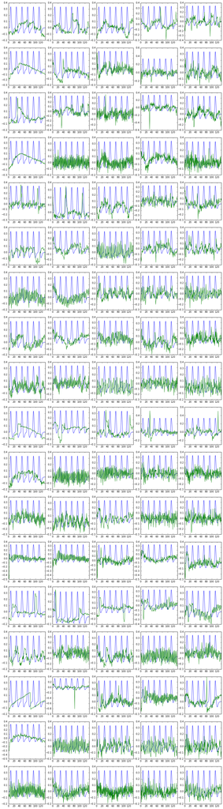

```python
tsteps = 136
frames = 176
e = np.true_divide(tsteps,frames)
e = np.multiply(e, frames-1)
t = np.linspace(0,e,frames)
plt.figure(figsize=(16,60))
for i in range(x.shape[0]):
    for j in range(x.shape[2]):
        r = x.shape[2]*i+j+1
        plt.subplot(x.shape[0], x.shape[2], r)
        plt.plot(t,y)
        plt.plot(t,x[i,:,j])
        plt.xlim(0,tsteps)
```

The hemodynamic response timeseries for the motor task was generated by the following code:

```python
import numpy as np
from nipy.modalities.fmri import hrf, utils
hrf_func = utils.lambdify_t(hrf.glover(utils.T))
tsteps = 214
frames = 284
e = np.true_divide(tsteps,frames)
e = np.multiply(e, frames-1)
t = np.linspace(0,e,frames)
h = hrf_func(t)
s = np.zeros(frames)
s[4]=1    # 3 sec
s[24]=1   # 18 sec
s[44]=1   # 33 sec
s[64]=1   # 48 sec
s[84]=1   # 63 sec
s[104]=1  # 78 sec
s[123]=1  # 93 sec
s[143]=1  # 108 sec
s[163]=1  # 123 sec
s[183]=1  # 138 sec
s[203]=1  # 153 sec
s[223]=1  # 168 sec
s[243]=1  # 183 sec
x = np.convolve(h,s)
x = x[:frames]
np.savetxt('./data/motor_output/hs_motor.txt', x)
```

This was then evaluated as follows:

```python
%matplotlib inline
import numpy as np
import matplotlib.pyplot as plt
tsteps = 284
wmc = 5
fnames = ['./wmreg_101107_motor.txt', './wmreg_102311_motor.txt', './wmreg_102816_motor.txt', \
          './wmreg_103515_motor.txt', './wmreg_106521_motor.txt', './wmreg_108828_motor.txt', \
          './wmreg_111312_motor.txt', './wmreg_111413_motor.txt', './wmreg_113619_motor.txt', \
          './wmreg_116524_motor.txt', './wmreg_118932_motor.txt', './wmreg_120515_motor.txt', \
          './wmreg_123925_motor.txt', './wmreg_130013_motor.txt', './wmreg_166438_motor.txt', \
          './wmreg_171431_motor.txt', './wmreg_180129_motor.txt', './wmreg_255639_motor.txt', \
          './wmreg_293748_motor.txt']
x = np.zeros((len(fnames),tsteps,wmc))
for i in range(x.shape[0]):
    x[i,:,:] = np.loadtxt(fnames[i])[:tsteps,:]
y = np.loadtxt('./hs_motor.txt')
coef = np.zeros((x.shape[0],wmc))
for i in range(x.shape[0]):
    for j in range(x.shape[2]):
        coef[i,j] = np.correlate(x[i,:,j],y)
coef_avg = np.zeros((1,wmc))
for k in range(coef.shape[1]):
    coef_avg[0,k] = np.mean(coef[:,k])
print "Average Correlation over each Component:"
print coef_avg
```

```
Average Correlation over each Component:
[[ 0.01077603 -0.01306154 -0.05181125  0.00780138 -0.01272943]]
```

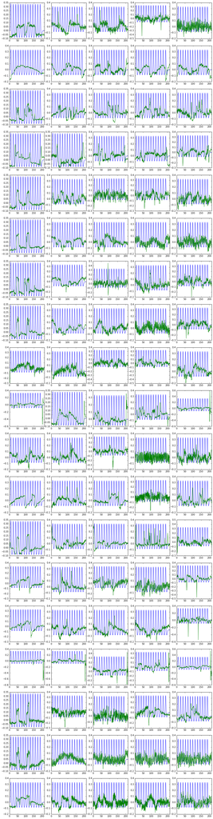

```python
tsteps = 214
frames = 284
e = np.true_divide(tsteps,frames)
e = np.multiply(e, frames-1)
t = np.linspace(0,e,frames)
plt.figure(figsize=(16,64))
for i in range(x.shape[0]):
    for j in range(x.shape[2]):
        r = x.shape[2]*i+j+1
        plt.subplot(x.shape[0], x.shape[2], r)
        plt.plot(t,y)
        plt.plot(t,x[i,:,j])
        plt.xlim(0,tsteps)
```

## Temporal High-Pass Filtering

Summary of information found [here](http://support.brainvoyager.com/functional-analysis-preparation/27-pre-processing/73-users-guide-temporal-high-pass-filtering.html):

Physiological and physical noise in fMRI data is typically of a low frequency. It can harm statistical data analysis, especially in the case of task-related events, so it is important to remove this noise from the data. Because it is typically low frequency, this can often be done by using a high-pass filter on the data, preserving higher frequencies. There are two general strategies for doing this: removing the noise in the preprocessing and performing the analysis on the denoised data or modeling the noise and including it as a confounding variable within the analysis.

High-pass filtering is performed on each voxel's timecourse (rather than all of them together), since each voxel can have its own drift from the noise. There are generally three methods for this filtering: using fourier analysis, using a GLM approach with a Fourier basis set in the design matrix, or using a GLM approach with a Discrete Cosine Transform (DCT) in the design matrix.

For the fourier transform method, the data is transformed, low frequencies below a specified cutoff are set to zero, and then the data is transformed back. This doesn't work well for linear trends, so a linear trend removal step is often applied beforehand. For the Fourier basis set GLM method, the filtering occurs in the time domain. The GLM estimates the contributions of the low frequencies by creating a design matrix of predictors (which are weighted by betas for the GLM) made of sines and cosines. A linear trend predictor is also added. Then, this design matrix is subtracted out of the original data to remove those frequencies. The other GLM method follows the same basic process, but instead of creating the design matrix from the Fourier basis set, it uses the DCT. This "roughly corresponds to a Fourier basis set with 2 sines and cosines (i.e. two cycles per time course)." This DCT basis set does not need the linear trend predictor as the Fourier basis set did since this information can be combined into the beta values. The three methods provide similar results, but this source (BrainVoyager) believes the GLM method with the Fourier basis set is slightly preferable.